# EEMB146 Lab 6 Exercise

Written by Samantha Sambado & Tatum Katz

2023-12-29

## Exercise 6 – Analysis of Variance Across Groups

# Learning Objectives

- Know the data structures of an **ANOVA**
  - factor : variable of interest
  - level/treatment: groups within factor that we’re interested in knowing the difference
- Know the **assumptions** of an ANOVA
- Know how to **create & test residuals**
  - new `plot(residual)` function to visualize assumptions
- Know when to perform a **post-hoc test**
  - If ANOVA significant, run post-hoc test (e.g. Tukey-Kramer)
  - If ANOVA not significant, no post-hoc

# Background

### Analysis of Variance (ANOVA)

We have now seen many different ways to compare the means of two groups. However, what if we have **more than two groups**? Unfortunately, we can’t just use a bunch of pairwise t-tests because this would inflate our Type I () error. **ANOVA is the answer**. It gives us a robust and powerful away to determine whether the means of three or more groups are different from each other. There are a couple terms that we need to familiarize ourselves with before we start using ANOVAs.

- **Factor**: Our variable of interest that we are changing. For example, if we were comparing the mean hearing frequency between different felines the factor would be feline and it would have different levels (i.e lion, tiger, and puma).
- **Level/group/treatment**: The levels of a factor are the groups that we are comparing. For example, the levels of the factor feline are lion, tiger, and puma.

### Assumptions of the ANOVA

Here are the assumptions of the ANOVA and how we test them:

1. Measurements from each group (level) represent a random sample from the corresponding population
   - Ensure that this assumption is met with your experimental design
2. Our response variable is normally distributed for each population
   - Test this assumption with a Q-Q plot and a Shapiro-Wilk test of the residuals
3. The variance is the same in all k populations (homogeneity of variance)
   - Test this assumption with a residual plot or a Levene’s Test.

### Hypotheses of the ANOVA

If we are comparing the means of k populations, the $H_0$ and $H_A$ of a **one-way ANOVA** are:

- $H_0$ : The mean of group 1 = mean of group 2 = mean of group k ($\mu_1 = \mu_2 = ... = \mu_k$)
- $H_0$ : At least one mean across the groups ($\mu_j$) is not equal

These hypotheses assert that any observation $i$ from group (level) is $j$, $y_{ij}$, can be calculated using the following equation: $y_{ij}= \mu_j +ϵ_{ij}$

Where $ϵ_{ij}$ is an error associated with the $i$ measurement from group $j$ and is normally distributed with mean 0 and some variance $σ^2ϵ$. The variance $σ^2ϵ$ is constant for all levels. This is just fancy notation for restating our two assumptions:

1. **Normality**
2. **Equality of Variance**

We could equivalently state the null hypotheses for the ANOVA as $H_0$ : $\alpha_1 = \alpha_2 =....= \alpha_j =...= \alpha_k = 0$

$H_A$ : At least one $\alpha_j$ is not equal to $0$

In this case, $\alpha_j$, is just the deviation of group $j$ from the grand mean $\mu$. The grand mean is the mean of all assumptions pooled across groups. **If all these deviations are $0$, there is no difference between our means**. These hypotheses assert that any observation i from group (level) $j$, $y_{ij}$, can be calculated using the following equation $y_{ij}=\mu+\alpha_j+\epsilon_{ij}$

If we reject our $H_0$, we have no information about which means are different, **just that at least one is different**.

### Testing the normality assumptions with residuals (NEW)

We’ve discussed how to test normality of individual variables within a data set. As we begin to build more complex models, we really are interested in whether the **residuals of those models are normally distributed**. In statistics, a **residual** refers to the amount of variability in a dependent variable (y) that is left over after accounting for the variability explained by the predictors (x) in your analysis. Essentially, when you model a relationship y~x, the residual is a numeric value for how wrong that modeled relationship is. Meaning, the higher the value of your residual, the more wrong your model is at capturing the relationship between y & x. Ideally you want to have residuals with lower values, but we’ll discuss the trade offs of having lower residuals but more complex models. More information about residuals can be found [here](http://www.statsmakemecry.com/smmctheblog/confusing-stats-terms-explained-residual.html).

**From here on out in the course, when we ask you to test normality, we are asking you to test the normality of your residuals and not the individual variables.** Because residuals can only be created after building a linear model (with lm() or aov() function), the order of testing for normality an variances will be different from Lab 4 and Lab 5. You will first fit the model and then evaluate the residuals for normality.

For now, here’s a sneak peek into how to test the normality of your residuals (see lab 5 video for more info):

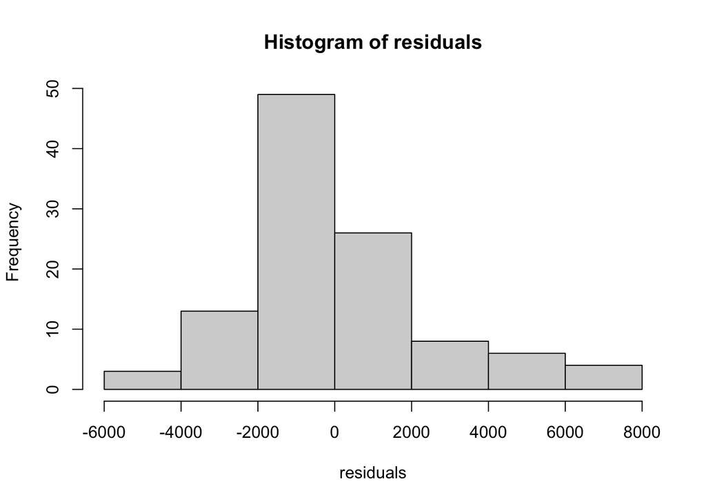

```r
## Step 1. Fit linear model
fit <- lm(concentration_pg_g ~ station, data = nwt_pikas)#run a linear model. lm(y~x) fits the equation y=mx+b
residuals <- fit$residuals#retrieve the residuals from the model

## Step 2. Check the normality of residuals
hist(residuals) # right skewed
```

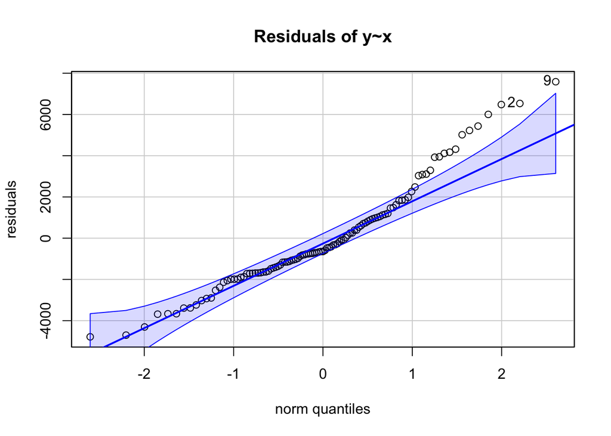

```
## [1] 9 2
```

```r
qqPlot(residuals, main = "Residuals of y~x")
```

```r
shapiro.test(residuals) #p < 0.05 so we reject the null; suggests that the data are non-normal
```

```
##
##  Shapiro-Wilk normality test
##
## data:  residuals
## W = 0.9482, p-value = 0.0003375
```

### New plots for visualizing normality assumptions (on your residuals)

In the above chunk, you built a linear model and made it into the object `fit`. In the next line you created the object `residuals` which contains the residuals from your fit linear model. We will explore how to visualize your assumptions with these new plots.

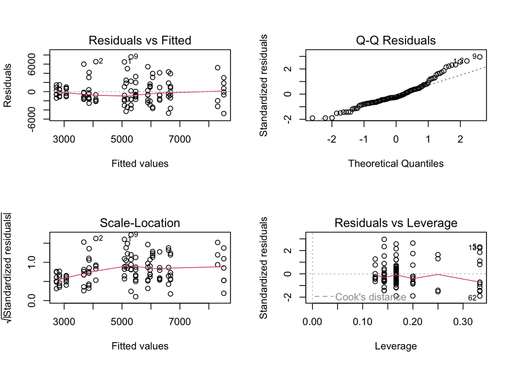

```r
par(mfrow = c(2,2)) # places 2 plots on 1 output view
plot(fit) #look at the diagnostic plots; focus on the first two plots (fitted vs residuals & QQ plot)
```

```r
par(mfrow=c(1,1)) # resets output view
```

While all the plots on this graph are useful, the two that we will focus on are the plots in the first row.

1. The first plot is called a residual plot and it is used to test our **Homogeneity of Variance (homoskedasticity)** assumption (i.e. plot titled **“Residuals vs. Fitted”**). It plots the values predicted by our lm model against the residuals of the model. If the residuals fall along the zero line for each treatment and don’t have any distinct pattern then we can be pretty confident that our assumption of equal variances is met. If this plot shows a distinct pattern, such as a wedge shape, there is good evidence that our assumptions of homogeneity of variance are not met and we might want to try a transformation.
2. The other plot that is useful in is the qqPlot of the residuals (i.e. plot titled **“Normal Q-Q”**). You have already seen a lot of the qqPlot so you know that if it deviates from a straight line the residuals likely do not follow a normal distribution. This would violated the **normality assumption** of the ANOVA.

This is where we depart from the code from Lab 4 and 5 in some big ways such as

- **running the lm/aov model first**, saving the residuals, and then testing the assumptions
- testing normality and evaluating variance of the **residuals**

# Exercises

## Exercise 1: ANOVA with a post-hoc test

For Exercise 1, we will be using the data set `maize`. The pollen of the corn (maize) plant is known to be a source of food to larval mosquitoes of the species *Anopheles arabiensis*, the main vector of malaria in Ethiopia. The production of maize has increased substantially in certain areas of Ethiopia recently, and over the same time malaria has entered in to new areas where it was previously rare.

This raises the question, is the increase of maize cultivation partly responsible for the increase in malaria? One line of evidence is to look for a geographical association on a smaller spatial scale between maize production and malaria incidence. The data set `maize` contains information on several high-altitude sites in Ethiopia, with information about the level of cultivation of maize (low, medium or high) and the rate of malaria per 10,000 people. Use an ANOVA to test **whether there is a difference in the mean number of malaria cases between the three levels of cultivation, `maize_yield`**.

**Step 1**. Check the data structures

```r
# For ANOVAs it is especially important data is structured in the way that is acceptable for the post-hoc tests. YOU MUST MAKE SURE YOU'RE FACTOR IS ACTUALLY A FACTOR FOR THE CODE TO WORK.

# str(maize)
# unique(maize$maize_yield)
maize$maize_yield <- as.factor(maize$maize_yield)
```

**Step 2**. Visualize the data - this is usally the first part before you can answer a question

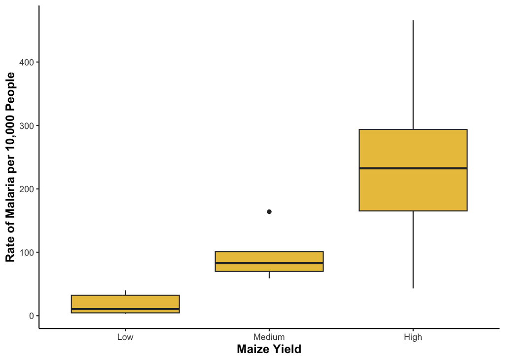

```r
ggplot(maize, aes(x = maize_yield, y = malaria_cases_per_10000)) +
  geom_boxplot(fill = "#eac34b") +
  theme_classic() +
  labs(x = "Maize Yield", y = "Rate of Malaria per 10,000 People")+
  theme(axis.title = element_text(face = "bold", size = 12)) +
  scale_x_discrete(limits = c("Low", "Medium", "High")) # change order of discrete labels
```

**Step 3**. Fit ANOVA model

```r
# HINT: aov(y ~ x, data = dataset)
mod1 <- aov(malaria_cases_per_10000 ~ maize_yield, # y~x formula
            data = maize)
```

**Step 4**. Check if the residuals meet ANOVA assumptions

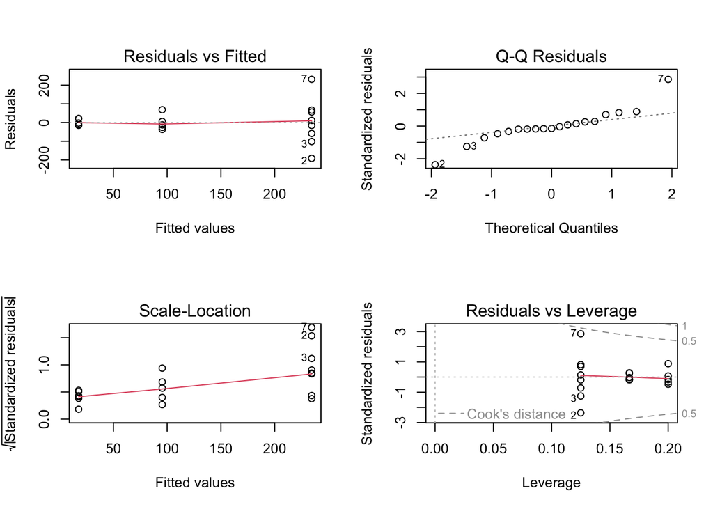

```r
par(mfrow = c(2,2)) # places 2 plots on 1 output view
plot(mod1) # new way to visualize normality & varaince assumptions
```

From Step 4, checking if the residuals meet the ANOVA assumptions, we focus on the top two graphs. The top left graph **“Residuals vs Fitted”** looks concerning because there is a cone shape of the residuals, meaning in the 3rd group of the fitted values, the 3rd group (High) has a lot more variation, which violates our assumption of the variances across all groups being equal. We will need to transform our data to reduce the variation of our residuals. In addition to that problem, the top right graph **“Q-Q Residuals”** also does not look like a straight line, suggesting our residuals are not normal so we should definitely do a transformation.

**Step 5**. Transform data and re-test assumptions

```r
min(maize$malaria_cases_per_10000) # check if there's 0s in data
```

```
## [1] 3
```

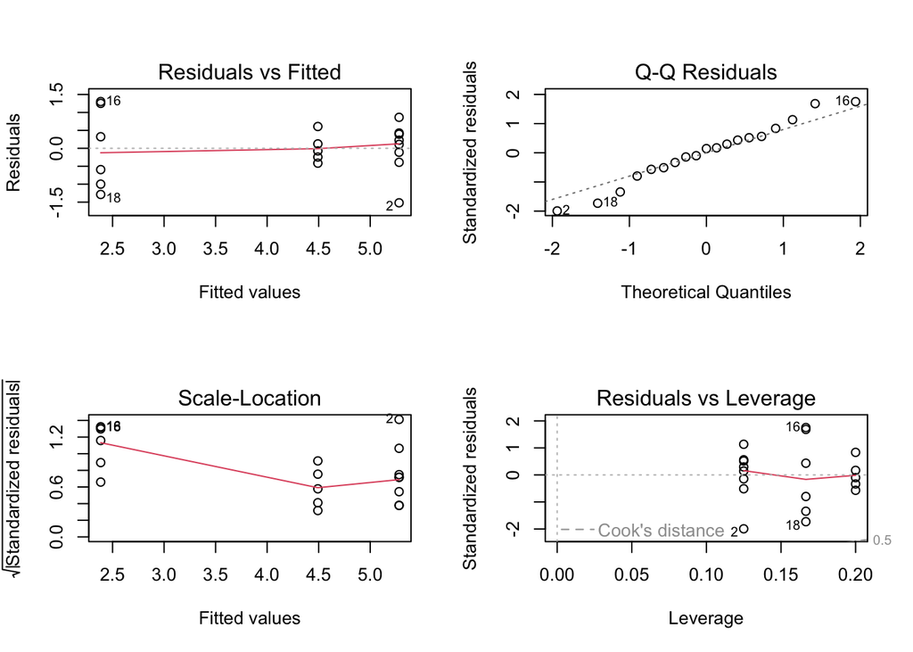

```r
maize$log_malaria_cases_per_10000 <- log(maize$malaria_cases_per_10000)

# re-run ANOVA with transformed data
mod2 <- aov(log_malaria_cases_per_10000 ~ maize_yield, data = maize)

# re-check if the residuals meet ANOVA assumptions
par(mfrow = c(2,2))
plot(mod2)
```

From our `mod2`, the diagnostic plots (“Residual vs Fitted” and “Q-Q Residuals”) look much better. There isn’t as much of a cone shape in top left and it’s a more straight line in top right. Since we have confirmed that our assumptions are met, we can now perform the rest of the ANOVA & post-hoc analysis on the LOG number of malaria cases per 10,000 people.

**Step 5**. Interpret ANOVA model that has met it’s assumptions

```r
summary(mod2) # THIS IS THE ANOVA TABLE WE ARE REFERRING TO IN HW QUESTIONS
```

```
##             Df Sum Sq Mean Sq F value   Pr(>F)
## maize_yield  2  29.49  14.744   22.22 2.41e-05 ***
## Residuals   16  10.62   0.663
## ---
## Signif. codes:  0 '***' 0.001 '**' 0.01 '*' 0.05 '.' 0.1 ' ' 1
```

As described in class, this table contains all of the information that was required to run the ANOVA. We see that we obtained an **F-value of 22.2** and a **p-value (2.41e-05)** less than $\alpha = 0.05$ allowing us to **reject the null hypothesis** and conclude that **at least one maize yield (low, medium, high) has significantly more or less** LOG malaria cases per 10,000 people than the others.

We just concluded from the above ANOVA that **at least one of the means differ**, but we often want to see which groups actually differ. We know we can’t do a bunch of t-tests because that will inflate our Type I error rate. We are instead going to use a method called a **Tukey-Kramer** test, which controls our Type I error rate. Here are some important notes about the Tukey-Kramer test:

- The Tukey-Kramer test assumes that you have **already run an ANOVA and rejected your null hypothesis**
- The Tukey-Kramer test does pairwise comparisons for all the groups we are testing and controls the family-wise Type I error rate so it is at most $\alpha = 0.05$ (it could be less).
- When your ANOVA is unbalanced (unequal sample sizes in each group), the Tukey-Kramer test is conservative, meaning that the family-wise Type I error is less than $\alpha = 0.05$ and it is harder for us to reject the null.
- The Tukey-Kramer test makes all of the same assumptions as the ANOVA

To run a Tukey-Kramer test for our maize yield ANOVA

** Step 6**. Run the post-hoc test after a significant ANOVA model

```r
# HINT: glht(ANOVA_MODEL, linfct = mcp(FACTOR = "Tukey)
?glht() # you'll see you need to have a factor for your mcp(argument)

post_hoc <- glht(mod2, # with your ANOVA model
                 linfct = mcp(maize_yield = "Tukey")) # if maize_yield is not a factor when you ran the mod2 anova, the glht() WILL NOT WORK

summary(post_hoc)
```

```
##
##   Simultaneous Tests for General Linear Hypotheses
##
## Multiple Comparisons of Means: Tukey Contrasts
##
##
## Fit: aov(formula = log_malaria_cases_per_10000 ~ maize_yield, data = maize)
##
## Linear Hypotheses:
##                    Estimate Std. Error t value Pr(>|t|)
## Low - High == 0     -2.8949     0.4399  -6.581   <0.001 ***
## Medium - High == 0  -0.7882     0.4644  -1.697   0.2361
## Medium - Low == 0    2.1068     0.4932   4.271   0.0016 **
## ---
## Signif. codes:  0 '***' 0.001 '**' 0.01 '*' 0.05 '.' 0.1 ' ' 1
## (Adjusted p values reported -- single-step method)
```

The plot of the confidence intervals generated from the Tukey-Kramer test for every pairwise combination of the groups. To interpret the table, notice that we see every pairwise combination of the levels of our factor. For each of these pairs, the Tukey-Kramer test has run a two-sample t-test and controlled for the family-wise Type I error. For example, **Low - High == 0** is referring to a pairwise test of whether the LOG mean number of malaria cases per 10,000 people in low yields is different than high yield locations (i.e. is the difference zero). We see that the **t=−6.581 and p<0.001** allowing us to conclude that there are significantly less LOG mean number of malaria cases per 10,000 people in low yield locations than high yield locations.

```r
cld(post_hoc) #compact letter display of Tukey groups
```

```
##   High    Low Medium
##    "a"    "b"    "a"
```

It is also really useful to look at the letters at the bottom of the output. Notice that High and Medium are labeled with the letter “a” and low is labeled with the letter “b”. **If two levels share a letter they are not significantly different**. If they do not share a letter they are significantly different. Notice that low does not share a letter with any of the other levels; therefore the LOG mean number of malaria cases per 10,000 people in low yield locations is significantly different than all other yield levels.

```r
confint(post_hoc) # shows your lower and upper CI bounds
```

```
##
##   Simultaneous Confidence Intervals
##
## Multiple Comparisons of Means: Tukey Contrasts
##
##
## Fit: aov(formula = log_malaria_cases_per_10000 ~ maize_yield, data = maize)
##
## Quantile = 2.577
## 95% family-wise confidence level
##
##
## Linear Hypotheses:
##                    Estimate lwr     upr
## Low - High == 0    -2.8949  -4.0286 -1.7613
## Medium - High == 0 -0.7882  -1.9848  0.4085
## Medium - Low == 0   2.1068   0.8357  3.3778
```

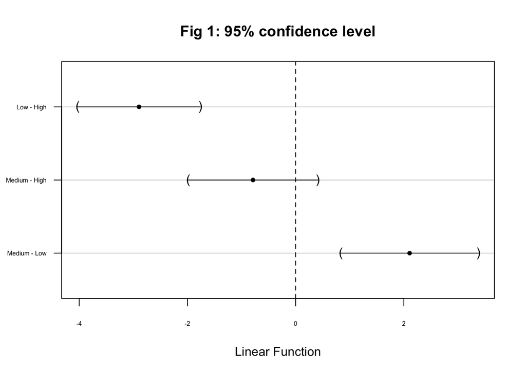

```r
plot(post_hoc, main = "Fig 1: 95% confidence level", #confidence intervals plotted
     cex.axis = .5) # make axis font smaller
```

```r
# the LOG mean number of malaria cases per 10,000 people for low maize yield is significantly different than all other levels (high, medium = a, low = b)
# if groups (1) have a different letter, (2) CIs don't overlap with 0 and (3) p-values significant, then they are statistically different.
```

## Exercise 2: ANOVA with no need for a post-hoc test

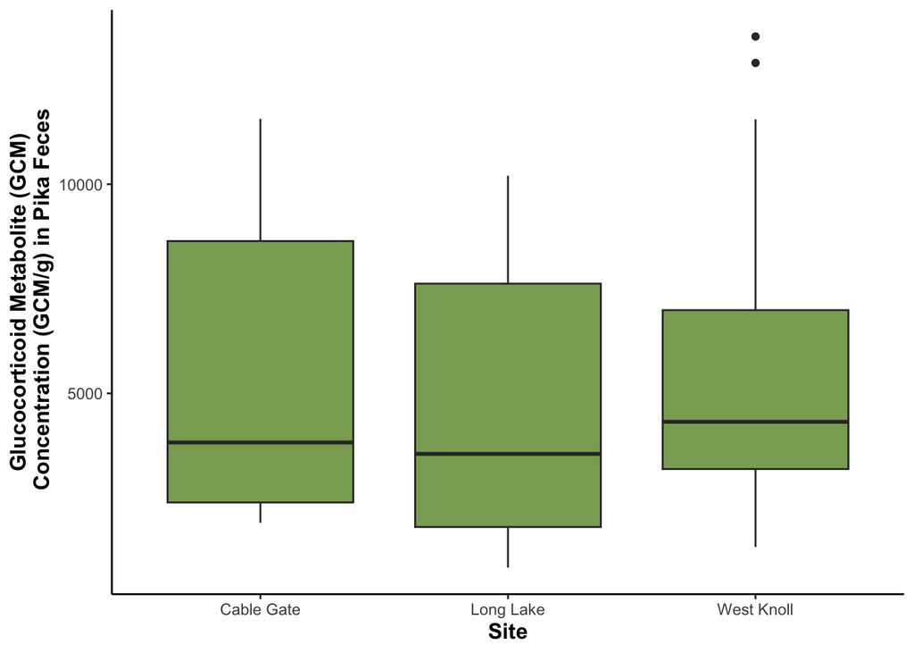

```r
# Step 0. Check data structures
# str(nwt_pikas) site is a factor

# Step 1. Visualize data
nwt_pikas %>%
  ggplot(aes(x = site, y = concentration_pg_g))+
  geom_boxplot(fill = "#8aaa61")+
  theme_classic() +
  labs(x = "Site", y = "Glucocorticoid Metabolite (GCM)\n Concentration (GCM/g) in Pika Feces")+
  theme(axis.title = element_text(face = "bold", size = 12))
```

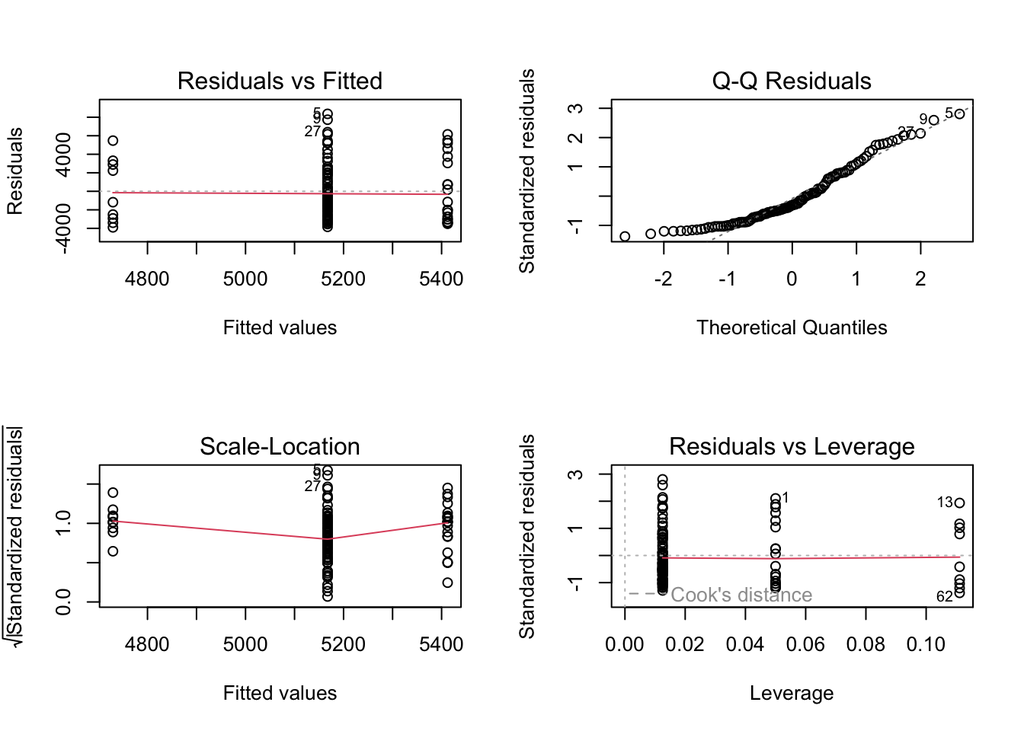

```r
# Step 2. Fit ANOVA model

mod3 <- aov(concentration_pg_g ~ site, # y~x formula
            data = nwt_pikas)

# Step 3. Check if the residuals meet ANOVA assumptions
par(mfrow = c(2,2))
plot(mod3) # seems normal
```

```r
# Step 4. Interpret ANOVA model that has met it's assumptions
summary(mod3)
```

```
##              Df    Sum Sq Mean Sq F value Pr(>F)
## site          2   2916699 1458350   0.162  0.851
## Residuals   106 953372140 8994077
```

As described in class, this table contains all of the information that was required to run the ANOVA. We see that we obtained an **F-value of 0.162 and a p-value (0.85)** greater than $\alpha = 0.05$, so we fail to reject the null hypothesis and conclude that none of the sites are signficiantly different in the mean total GCM concentration in pika feces. **Because our ANOVA model is not significant, there is no reason to run a post-hoc** (e.g. Tukey-Kramer) test to find which of the groups is different from one another.

## Exercise 3. Power Analysis

If you do any research at all, you will be asked to run power analysis before spending more time or energy on a project. For now, we will just give you a very quick exercise on power analysis that we encourage you to look up more in your own time, particularly [this resource](https://ladal.edu.au/pwr.html#Introduction).

We will show you to perform a power test on a one way ANOVA (aka Lab 6). However you will need to run different power tests fo chi-square tests, correlations, linear model, paired t-test, and two sample t-test with unequal sample size. You need 3 out of 4 parameters to run a power analysis: effect size, sample size, significance level, and power. Whichever 3 you plug into the analysis, the analsysi will calculate the 4th.

```r
pwr.anova.test(k = 4,  # 4 groups are compared
               f = .25, # moderate effect size
               sig.level = .05, # alpha/sig level
               power = .8) # confint./power
```

```
##
##      Balanced one-way analysis of variance power calculation
##
##               k = 4
##               n = 44.59927
##               f = 0.25
##       sig.level = 0.05
##           power = 0.8
##
## NOTE: n is number in each group
```

In this case the minimum number of participants in each group would be 45 (remember you can’t have .5 of a study subject, round up).

But what if you already collected the data (from 20 participants) and you want to make sure you have enough statistical power to report on your analysis. We’re assuming moderate effect size.

```r
pwr.anova.test(k = 4,  # 4 groups are compared
               f = .25, # moderate effect size
               sig.level = .05, # alpha/sig level
               n = 20) # n of participants
```

```
##
##      Balanced one-way analysis of variance power calculation
##
##               k = 4
##               n = 20
##               f = 0.25
##       sig.level = 0.05
##           power = 0.4203901
##
## NOTE: n is number in each group
```

Uh oh, in this case our analysis suggests we only have a power of 0.42, meaning we would only detect a medium sized effect in 42 % of cases, which is considered insufficient – time to gather more data!

# Additional Resources for Final Project

For your Final Project, you will be responsible for creating a professional looking report about a biological system you investigated using statistical tests and R skills you learned throughout EEMB 146. Historically most students choose an ANOVA as one of their statistical tests so I will leave some more resources to peruse through.

[Introduction to ANOVA video](https://www.youtube.com/watch?v=FLyCZnjuJVA&feature=youtu.be) – video for audio learners

[ANOVA blog](https://medium.com/@StepUpAnalytics/anova-one-way-vs-two-way-6b3ff87d3a94) – 1 way vs 2 way ANOVA

# Vocab

- Type I error (false positive): occurs if an investigator rejects a null hypothesis that is actually true in the population
- Type II error (false negative): occurs if the investigator fails to reject a null hypothesis that is actually false in the population

### End of Exercise 6